# DATS 6101 Midterm

3/5/22

```r
#' Original outlierKD function by By Klodian Dhana,
#' https://www.r-bloggers.com/identify-describe-plot-and-remove-the-outliers-from-the-dataset/
#' Modified to have third argument for removing outliers instead of interactive prompt,
#' and after removing outlier, original df will not be changed. The function returns the a df,
#' which can be saved as original df name if desired.
#' Also added QQ-plot in the output, with options to show/hide boxplot, histogram, qqplot.
#' Check outliers, and option to remove them, save as a new dataframe.
#' @param df The dataframe.
#' @param var The variable in the dataframe to be checked for outliers
#' @param rm Boolean. Whether to remove outliers or not.
#' @param boxplt Boolean. Whether to show the boxplot, before and after outliers removed.
#' @param histogram Boolean. Whether to show the histogram, before and after outliers removed.
#' @param qqplt Boolean. Whether to show the qqplot, before and after outliers removed.
#' @return The dataframe with outliers replaced by NA if rm==TRUE, or df if nothing changed
#' @examples
#'   outlierKD2(mydf, height, FALSE, TRUE, TRUE, TRUE)
#'   mydf = outlierKD2(mydf, height, TRUE, TRUE, TRUE, TRUE)
#'   mydfnew = outlierKD2(mydf, height, TRUE)
#' @export
outlierKD2 <- function(df, var, rm=TRUE, boxplt=TRUE, histogram=TRUE, qqplt=TRUE) {
  dt = df # duplicate the dataframe for potential alteration
  var_name <- eval(substitute(var),eval(dt))
  na1 <- sum(is.na(var_name))
  m1 <- mean(var_name, na.rm = T)
  colTotal <- boxplt+histogram+qqplt
  par(mfrow=c(2, max(2,colTotal)), oma=c(0,0,3,0)) # fixed issue with only 0 or 1 chart selected
  if (qqplt) {
    qqnorm(var_name, main = "With outliers")
    qqline(var_name)
  }
  if (histogram) { hist(var_name, main="With outliers", xlab=NA, ylab=NA) }
  if (boxplt) { boxplot(var_name, main="With outliers") }

  outlier <- boxplot.stats(var_name)$out
  mo <- mean(outlier)
  var_name <- ifelse(var_name %in% outlier, NA, var_name)
  if (qqplt) {
    qqnorm(var_name, main = "Without outliers")
    qqline(var_name)
  }
  if (histogram) { hist(var_name, main="Without outliers", xlab=NA, ylab=NA) }
  if (boxplt) { boxplot(var_name, main="Without outliers") }

  if(colTotal > 0) {  # if no charts are wanted, skip this section
    title("Outlier Check", outer=TRUE)
    na2 <- sum(is.na(var_name))
    cat("Outliers identified:", na2 - na1, "\n")
    cat("Propotion (%) of outliers:", round((na2 - na1) / sum(!is.na(var_name))*100, 1), "\n")
    cat("Mean of the outliers:", round(mo, 2), "\n")
    m2 <- mean(var_name, na.rm = T)
    cat("Mean without removing outliers:", round(m1, 2), "\n")
    cat("Mean if we remove outliers:", round(m2, 2), "\n")
  }

  # response <- readline(prompt="Do you want to remove outliers and to replace with NA? [yes/no]: ")
  # if(response == "y" | response == "yes"){
  if(rm){
      dt[as.character(substitute(var))] <- invisible(var_name)
      #assign(as.character(as.list(match.call())$dt), dt, envir = .GlobalEnv)
      cat("Outliers successfully removed", "\n")
      return(invisible(dt))
  } else {
      cat("Nothing changed", "\n")
      return(invisible(df))
  }
}
```

### Research Topic:

There is considerable evidence indicating lending disparities throughout the United States. (Steil et. al: 2018). For our research topic, we will explore lending practices in one of the fastest appreciating real estate markets over the past thirty years - the state of California. Specifically, we aim to look at the factors that are associated with denials for non-commercial mortgage loans.

Our SMART question is:

“Which factors drove denials for mortgages in California in 2019?”

Our Github repository address is:https://github.com/brandonchin19/Team3/.

### Load in dataset

```r
hmda<-read.csv("2019_lar.csv")
str(hmda)
```

```
## 'data.frame':    10000 obs. of  99 variables:
##  $ activity_year                           : int  2019 2019 2019 2019 2019 2019 2019 2019 2019 2019 ...
##  $ lei                                     : chr  "254900VHUBSJJKOMBF27" "254900VHUBSJJKOMBF27" "254900VHUBSJJKOMBF27" "254900VHUBSJJKOMBF27" ...
##  $ derived_msa_md                          : int  13460 13460 31084 40140 31084 31084 31084 40140 31084 40140 ...
##  $ state_code                              : chr  "OR" "OR" "CA" "CA" ...
##  $ county_code                             : int  41017 41017 6037 6071 6037 6037 6037 6071 6037 6071 ...
##  $ census_tract                            : num  4.10e+10 4.10e+10 6.04e+09 6.07e+09 6.04e+09 ...
##  $ conforming_loan_limit                   : chr  "C" "C" "C" "C" ...
##  $ derived_loan_product_type               : chr  "Conventional:First Lien" "FHA:First Lien" "Conventional:First Lien" "Conventional:First Lien" ...
##  $ derived_dwelling_category               : chr  "Single Family (1-4 Units):Site-Built" "Single Family (1-4 Units):Manufactured" "Single Family (1-4 Units):Site-Built" "Single Family (1-4 Units):Site-Built" ...
##  $ derived_ethnicity                       : chr  "Hispanic or Latino" "Not Hispanic or Latino" "Hispanic or Latino" "Joint" ...
##  $ derived_race                            : chr  "White" "White" "White" "White" ...
##  $ derived_sex                             : chr  "Joint" "Joint" "Male" "Joint" ...
##  $ action_taken                            : int  1 1 4 4 4 1 1 4 4 4 ...
##  $ purchaser_type                          : int  71 0 0 0 0 1 71 0 0 0 ...
```

[output cut: 85 more lines]

# Check number of rows

```r
nrow(hmda)
```

```
## [1] 10000
```

# Check head and tail of dataframe

```r
xkabledplyhead(hmda,5)
```

Head

| activity_year | lei | derived_msa_md | state_code | county_code | census_tract | conforming_loan_limit | derived_loan_product_type | derived_dwelling_category | derived_ethnicity | derived_race | derived_sex | action_taken | purchaser_type | preapproval | loan_type | loan_purpose | lien_status | reverse_mortgage | open_end_line_of_credit | business_or_commercial_purpose | loan_amount | combined_loan_to_value_ratio | interest_rate | rate_spread | hoepa_status | total_loan_costs | total_points_and_fees | origination_charges | discount_points | … |
| --- | --- | --- | --- | --- | --- | --- | --- | --- | --- | --- | --- | --- | --- | --- | --- | --- | --- | --- | --- | --- | --- | --- | --- | --- | --- | --- | --- | --- | --- | --- |
| 2019 | 254900VHUBSJJKOMBF27 | 13460 | OR | 41017 | 4.10e+10 | C | Conventional:First Lien | Single Family (1-4 Units):Site-Built | Hispanic or Latino | White | Joint | 1 | 71 | 2 | 1 | 32 | 1 | 2 | 2 | 2 | 245000 | 62.03 | 4.624 | 1.138 | 2 | 5649.75 | NA | 3303.75 | NA | … |
| 2019 | 254900VHUBSJJKOMBF27 | 13460 | OR | 41017 | 4.10e+10 | C | FHA:First Lien | Single Family (1-4 Units):Manufactured | Not Hispanic or Latino | White | Joint | 1 | 0 | 2 | 2 | 1 | 1 | 2 | 2 | 2 | 385000 | 96.5 | 4.125 | 1.458 | 2 | 13905.13 | NA | 4923.5 | NA | … |
| 2019 | 254900VHUBSJJKOMBF27 | 31084 | CA | 6037 | 6.04e+09 | C | Conventional:First Lien | Single Family (1-4 Units):Site-Built | Hispanic or Latino | White | Male | 4 | 0 | 2 | 1 | 32 | 1 | 2 | 2 | 2 | 695000 | NA | NA | NA | 3 | NA | NA | NA | NA | … |
| 2019 | 254900VHUBSJJKOMBF27 | 40140 | CA | 6071 | 6.07e+09 | C | Conventional:First Lien | Single Family (1-4 Units):Site-Built | Joint | White | Joint | 4 | 0 | 2 | 1 | 31 | 1 | 2 | 2 | 2 | 325000 | NA | NA | NA | 3 | NA | NA | NA | NA | … |
| 2019 | 254900VHUBSJJKOMBF27 | 31084 | CA | 6037 | 6.04e+09 | C | Conventional:First Lien | Single Family (1-4 Units):Site-Built | Hispanic or Latino | White | Male | 4 | 0 | 2 | 1 | 31 | 1 | 2 | 2 | 2 | 345000 | NA | NA | NA | 3 | NA | NA | NA | NA | … |

```r
xkabledplytail(hmda,5)
```

Tail

|  | activity_year | lei | derived_msa_md | state_code | county_code | census_tract | conforming_loan_limit | derived_loan_product_type | derived_dwelling_category | derived_ethnicity | derived_race | derived_sex | action_taken | purchaser_type | preapproval | loan_type | loan_purpose | lien_status | reverse_mortgage | open_end_line_of_credit | business_or_commercial_purpose | loan_amount | combined_loan_to_value_ratio | interest_rate | rate_spread | hoepa_status | total_loan_costs | total_points_and_fees | origination_charges | … |
| --- | --- | --- | --- | --- | --- | --- | --- | --- | --- | --- | --- | --- | --- | --- | --- | --- | --- | --- | --- | --- | --- | --- | --- | --- | --- | --- | --- | --- | --- | --- |
| 9996 | 2019 | 5493008CPTDVOS570626 | 15980 | FL | 12071 | 1.21e+10 | C | Conventional:Subordinate Lien | Single Family (1-4 Units):Site-Built | Joint | White | Joint | 1 | 0 | 2 | 1 | 2 | 2 | 2 | 1 | 2 | 55000 | 78.63 | 4.49 | -0.71 | 2 | NA | NA | NA | … |
| 9997 | 2019 | 5493008CPTDVOS570626 | 15980 | FL | 12071 | 1.21e+10 | C | Conventional:Subordinate Lien | Single Family (1-4 Units):Site-Built | Not Hispanic or Latino | White | Joint | 3 | 0 | 2 | 1 | 4 | 2 | 2 | 1 | 2 | 115000 | 92.15 | NA | NA | 3 | NA | NA | NA | … |
| 9998 | 2019 | 5493008CPTDVOS570626 | 17460 | OH | 39055 | 3.91e+10 | C | Conventional:Subordinate Lien | Single Family (1-4 Units):Site-Built | Not Hispanic or Latino | White | Male | 1 | 0 | 2 | 1 | 31 | 2 | 2 | 1 | 2 | 75000 | 43.86 | 4.49 | -0.71 | 2 | NA | NA | NA | … |
| 9999 | 2019 | 5493008CPTDVOS570626 | 35004 | NY | 36059 | 3.61e+10 | C | Conventional:Subordinate Lien | Single Family (1-4 Units):Site-Built | Not Hispanic or Latino | Asian | Male | 3 | 0 | 2 | 1 | 2 | 2 | 2 | 1 | 2 | 45000 | 72.54 | NA | NA | 3 | NA | NA | NA | … |
| 10000 | 2019 | 5493008CPTDVOS570626 | 42644 | WA | 53033 | 5.30e+10 | C | Conventional:Subordinate Lien | Single Family (1-4 Units):Site-Built | Ethnicity Not Available | Race Not Available | Sex Not Available | 1 | 0 | 2 | 1 | 31 | 2 | 2 | 1 | 2 | 95000 | 54.84 | 4.49 | -0.71 | 2 | NA | NA | NA | … |

# Subsetting to California Only

```r
hmda_ca <- subset(hmda,state_code=="CA")
str(hmda_ca)
```

```
## 'data.frame':    5441 obs. of  99 variables:
##  $ activity_year                           : int  2019 2019 2019 2019 2019 2019 2019 2019 2019 2019 ...
##  $ lei                                     : chr  "254900VHUBSJJKOMBF27" "254900VHUBSJJKOMBF27" "254900VHUBSJJKOMBF27" "254900VHUBSJJKOMBF27" ...
##  $ derived_msa_md                          : int  31084 40140 31084 31084 31084 40140 31084 40140 31084 31084 ...
##  $ state_code                              : chr  "CA" "CA" "CA" "CA" ...
##  $ county_code                             : int  6037 6071 6037 6037 6037 6071 6037 6071 6037 6037 ...
##  $ census_tract                            : num  6.04e+09 6.07e+09 6.04e+09 6.04e+09 6.04e+09 ...
##  $ conforming_loan_limit                   : chr  "C" "C" "C" "C" ...
##  $ derived_loan_product_type               : chr  "Conventional:First Lien" "Conventional:First Lien" "Conventional:First Lien" "Conventional:First Lien" ...
##  $ derived_dwelling_category               : chr  "Single Family (1-4 Units):Site-Built" "Single Family (1-4 Units):Site-Built" "Single Family (1-4 Units):Site-Built" "Single Family (1-4 Units):Site-Built" ...
##  $ derived_ethnicity                       : chr  "Hispanic or Latino" "Joint" "Hispanic or Latino" "Hispanic or Latino" ...
##  $ derived_race                            : chr  "White" "White" "White" "White" ...
##  $ derived_sex                             : chr  "Male" "Joint" "Male" "Female" ...
##  $ action_taken                            : int  4 4 4 1 1 4 4 4 4 4 ...
##  $ purchaser_type                          : int  0 0 0 1 71 0 0 0 0 0 ...
```

[output cut: 85 more lines]

# Subsetting to California Only; non-business properties; principal residences only

```r
hmda_ca <- subset(hmda_ca,business_or_commercial_purpose=="2")
str(hmda_ca)
```

```
## 'data.frame':    5196 obs. of  99 variables:
##  $ activity_year                           : int  2019 2019 2019 2019 2019 2019 2019 2019 2019 2019 ...
##  $ lei                                     : chr  "254900VHUBSJJKOMBF27" "254900VHUBSJJKOMBF27" "254900VHUBSJJKOMBF27" "254900VHUBSJJKOMBF27" ...
##  $ derived_msa_md                          : int  31084 40140 31084 31084 31084 31084 31084 31084 31084 31084 ...
##  $ state_code                              : chr  "CA" "CA" "CA" "CA" ...
##  $ county_code                             : int  6037 6071 6037 6037 6037 6037 6037 6037 6037 6037 ...
##  $ census_tract                            : num  6.04e+09 6.07e+09 6.04e+09 6.04e+09 6.04e+09 ...
##  $ conforming_loan_limit                   : chr  "C" "C" "C" "C" ...
##  $ derived_loan_product_type               : chr  "Conventional:First Lien" "Conventional:First Lien" "Conventional:First Lien" "Conventional:First Lien" ...
##  $ derived_dwelling_category               : chr  "Single Family (1-4 Units):Site-Built" "Single Family (1-4 Units):Site-Built" "Single Family (1-4 Units):Site-Built" "Single Family (1-4 Units):Site-Built" ...
##  $ derived_ethnicity                       : chr  "Hispanic or Latino" "Joint" "Hispanic or Latino" "Hispanic or Latino" ...
##  $ derived_race                            : chr  "White" "White" "White" "White" ...
##  $ derived_sex                             : chr  "Male" "Joint" "Male" "Female" ...
##  $ action_taken                            : int  4 4 4 1 1 4 4 4 1 1 ...
##  $ purchaser_type                          : int  0 0 0 1 71 0 0 0 71 71 ...
```

[output cut: 85 more lines]

```r
hmda_ca <- subset(hmda_ca,occupancy_type=="1")
str(hmda_ca)
```

```
## 'data.frame':    5147 obs. of  99 variables:
##  $ activity_year                           : int  2019 2019 2019 2019 2019 2019 2019 2019 2019 2019 ...
##  $ lei                                     : chr  "254900VHUBSJJKOMBF27" "254900VHUBSJJKOMBF27" "254900VHUBSJJKOMBF27" "254900VHUBSJJKOMBF27" ...
##  $ derived_msa_md                          : int  31084 40140 31084 31084 31084 31084 31084 31084 31084 31084 ...
##  $ state_code                              : chr  "CA" "CA" "CA" "CA" ...
##  $ county_code                             : int  6037 6071 6037 6037 6037 6037 6037 6037 6037 6037 ...
##  $ census_tract                            : num  6.04e+09 6.07e+09 6.04e+09 6.04e+09 6.04e+09 ...
##  $ conforming_loan_limit                   : chr  "C" "C" "C" "C" ...
##  $ derived_loan_product_type               : chr  "Conventional:First Lien" "Conventional:First Lien" "Conventional:First Lien" "Conventional:First Lien" ...
##  $ derived_dwelling_category               : chr  "Single Family (1-4 Units):Site-Built" "Single Family (1-4 Units):Site-Built" "Single Family (1-4 Units):Site-Built" "Single Family (1-4 Units):Site-Built" ...
##  $ derived_ethnicity                       : chr  "Hispanic or Latino" "Joint" "Hispanic or Latino" "Hispanic or Latino" ...
##  $ derived_race                            : chr  "White" "White" "White" "White" ...
##  $ derived_sex                             : chr  "Male" "Joint" "Male" "Female" ...
##  $ action_taken                            : int  4 4 4 1 1 4 4 4 1 1 ...
##  $ purchaser_type                          : int  0 0 0 1 71 0 0 0 71 71 ...
```

[output cut: 85 more lines]

# Subsetting to only relevant columns

```r
hmda_ca_final <- hmda_ca[c(10,11,12,13,22,24,39,46,50, 62,74,78)]
str(hmda_ca_final)
```

```
## 'data.frame':    5147 obs. of  12 variables:
##  $ derived_ethnicity    : chr  "Hispanic or Latino" "Joint" "Hispanic or Latino" "Hispanic or Latino" ...
##  $ derived_race         : chr  "White" "White" "White" "White" ...
##  $ derived_sex          : chr  "Male" "Joint" "Male" "Female" ...
##  $ action_taken         : int  4 4 4 1 1 4 4 4 1 1 ...
##  $ loan_amount          : int  695000 325000 345000 415000 485000 465000 495000 475000 475000 485000 ...
##  $ interest_rate        : chr  NA NA NA "4.75" ...
##  $ property_value       : chr  NA NA NA "525000" ...
##  $ income               : int  141 126 74 90 165 112 89 112 90 112 ...
##  $ applicant_ethnicity_1: int  1 2 1 1 1 1 1 3 1 1 ...
##  $ applicant_race_1     : int  5 5 5 5 5 5 5 6 5 5 ...
##  $ applicant_sex        : int  1 1 1 2 2 1 2 3 1 1 ...
##  $ applicant_age        : chr  "55-64" "25-34" "45-54" "55-64" ...
```

# Changing vector types

```r
hmda_ca_final_1 = hmda_ca_final
hmda_ca_final_1$derived_ethnicity = factor(hmda_ca_final$derived_ethnicity)
hmda_ca_final_1$derived_race = factor(hmda_ca_final$derived_race)
hmda_ca_final_1$derived_sex = factor(hmda_ca_final$derived_sex)
hmda_ca_final_1$action_taken = factor(hmda_ca_final$action_taken)
hmda_ca_final_1$loan_amount = as.numeric(hmda_ca_final$loan_amount)
hmda_ca_final_1$interest_rate = as.numeric(hmda_ca_final$interest_rate)
hmda_ca_final_1$property_value = as.numeric(hmda_ca_final$property_value)
hmda_ca_final_1$income = as.numeric(hmda_ca_final$income)
hmda_ca_final_1$applicant_age = factor(hmda_ca_final$applicant_age)
str(hmda_ca_final_1)
```

```
## 'data.frame':    5147 obs. of  12 variables:
##  $ derived_ethnicity    : Factor w/ 5 levels "Ethnicity Not Available",..: 3 4 3 3 3 3 3 1 3 3 ...
##  $ derived_race         : Factor w/ 8 levels "2 or more minority races",..: 8 8 8 8 8 8 8 7 8 8 ...
##  $ derived_sex          : Factor w/ 4 levels "Female","Joint",..: 3 2 3 1 2 3 1 4 3 3 ...
##  $ action_taken         : Factor w/ 5 levels "1","2","3","4",..: 4 4 4 1 1 4 4 4 1 1 ...
##  $ loan_amount          : num  695000 325000 345000 415000 485000 465000 495000 475000 475000 485000 ...
##  $ interest_rate        : num  NA NA NA 4.75 4.5 NA NA NA 4.75 4.5 ...
##  $ property_value       : num  NA NA NA 525000 495000 NA NA NA 475000 495000 ...
##  $ income               : num  141 126 74 90 165 112 89 112 90 112 ...
##  $ applicant_ethnicity_1: int  1 2 1 1 1 1 1 3 1 1 ...
##  $ applicant_race_1     : int  5 5 5 5 5 5 5 6 5 5 ...
##  $ applicant_sex        : int  1 1 1 2 2 1 2 3 1 1 ...
##  $ applicant_age        : Factor w/ 7 levels "<25",">74","25-34",..: 6 3 5 6 4 3 3 6 5 3 ...
```

# Histograms and Box Plots

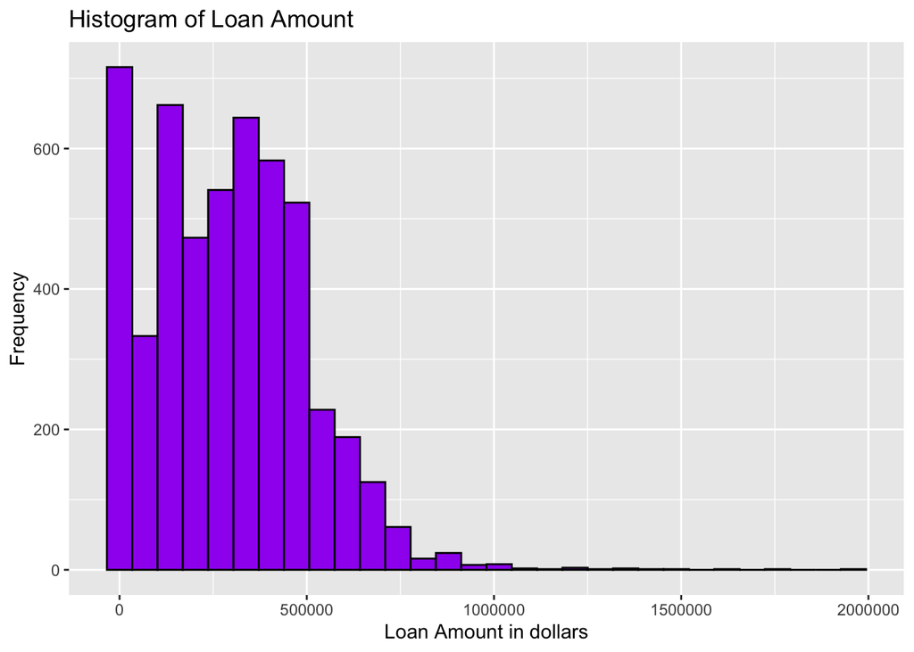

```r
library(ggplot2)
ggplot(hmda_ca_final_1,aes(x=loan_amount))+
  geom_histogram(color="black", fill="purple")+
  labs(title="Histogram of Loan Amount", x="Loan Amount in dollars", y="Frequency")
```

Loan amount distribution does not appear to be normal (mean is greater than the median).

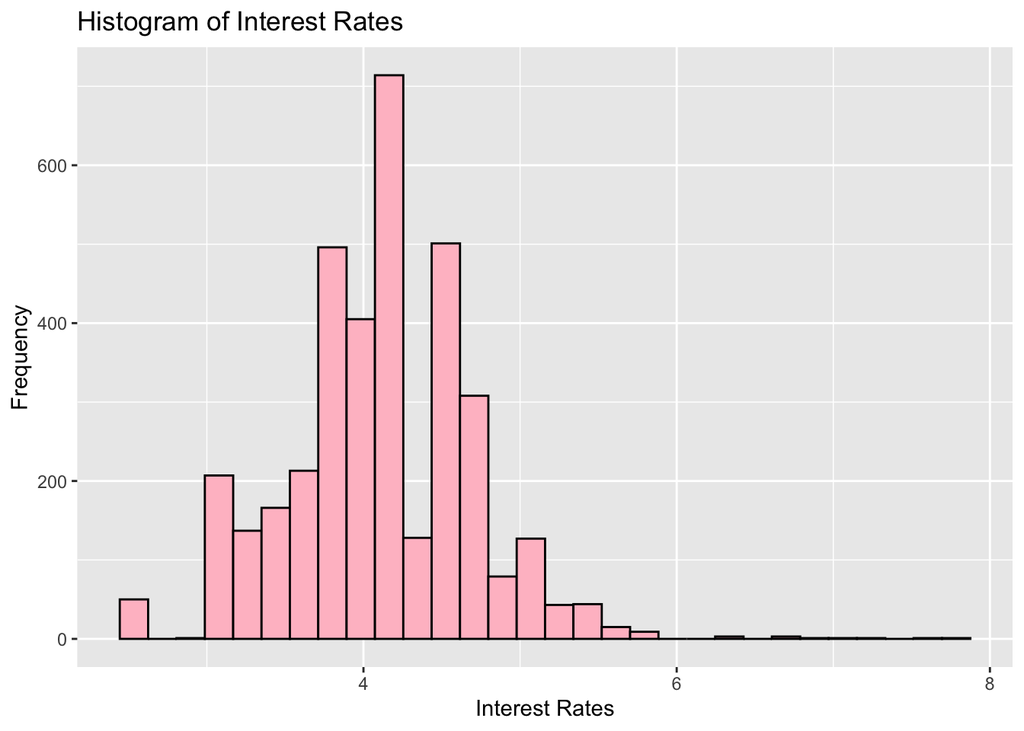

```r
library(ggplot2)
ggplot(hmda_ca_final_1,aes(x=interest_rate))+
  geom_histogram(color="black", fill="pink")+
  labs(title="Histogram of Interest Rates", x="Interest Rates", y="Frequency")
```

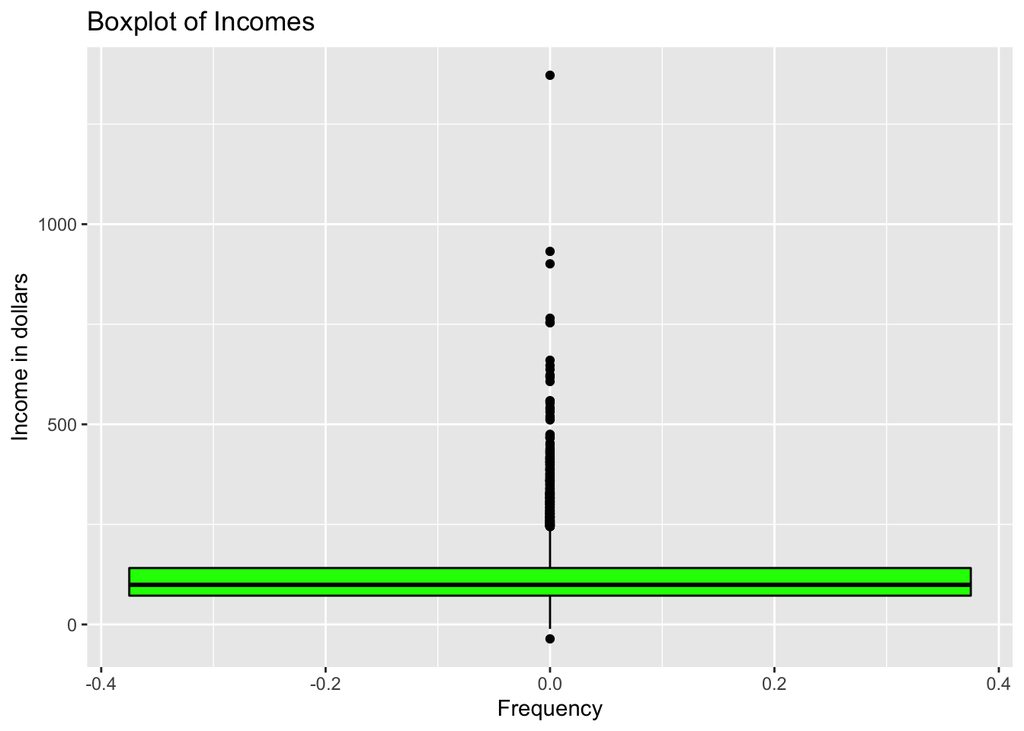

```r
ggplot(hmda_ca,aes(y=income))+
  geom_boxplot(color="black", fill="green")+
  labs(title="Boxplot of Incomes", y="Income in dollars", x="Frequency")
```

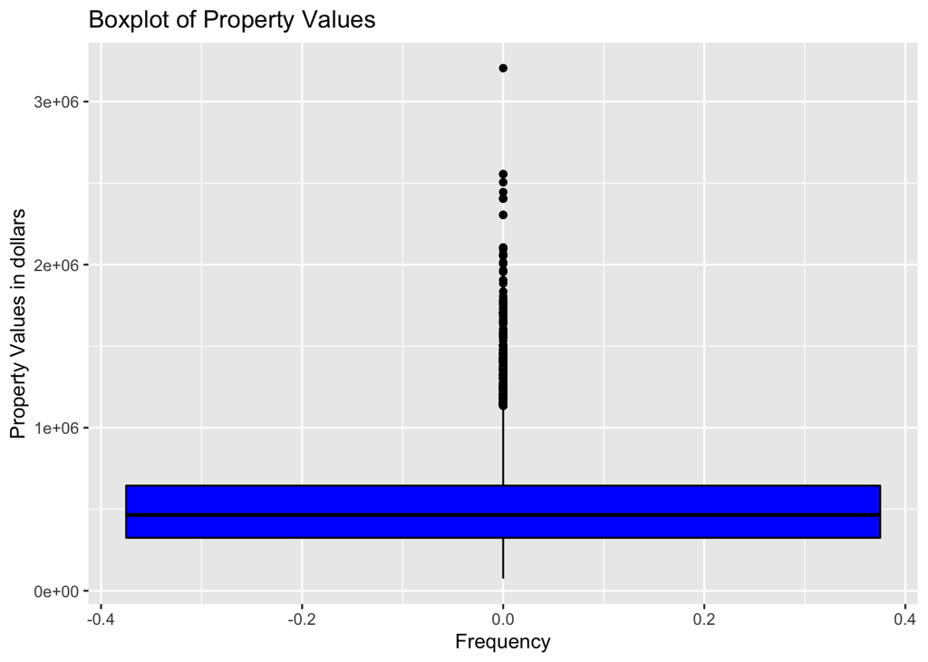

```r
ggplot(hmda_ca_final_1,aes(y=property_value))+
  geom_boxplot(color="black", fill="blue")+
  labs(title="Boxplot of Property Values", y="Property Values in dollars", x="Frequency")
```

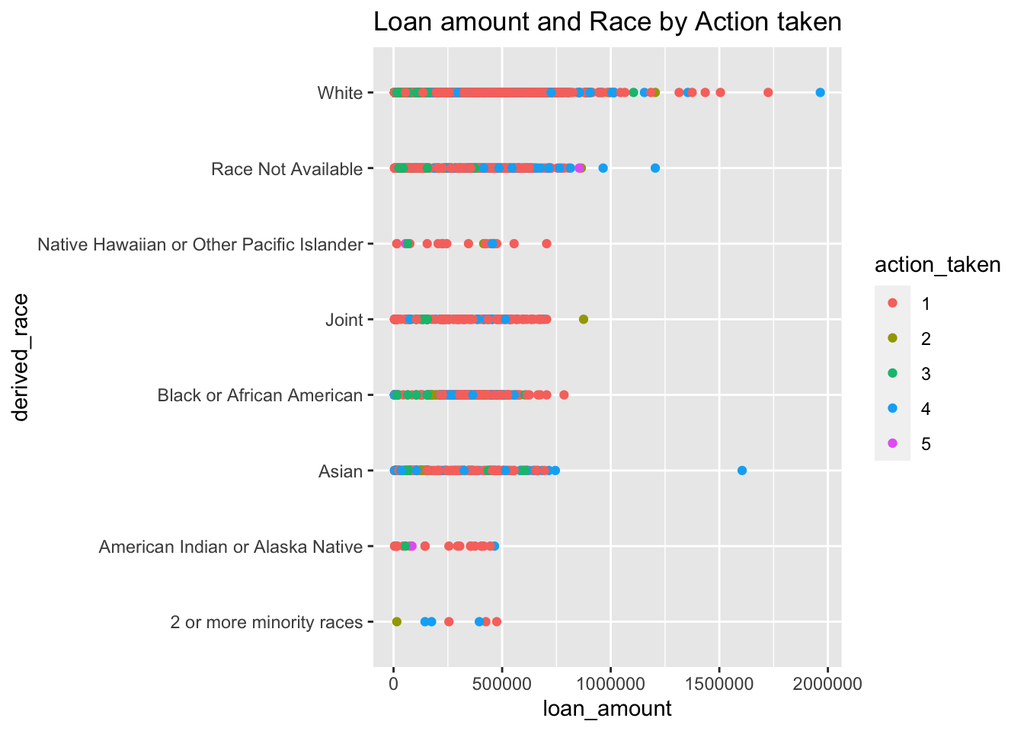

```r
library(ggplot2)
qplot(data = hmda_ca_final_1,
      x = loan_amount,
      y = derived_race,
      color = action_taken,
      main="Loan amount and Race by Action taken")
```

# Exploring columns that appear to have lots of NAs

```r
summary(hmda_ca_final_1$interest_rate)
```

```
##    Min. 1st Qu.  Median    Mean 3rd Qu.    Max.    NA's
##       2       4       4       4       4       8    1493
```

```r
summary(hmda_ca_final_1$property_value)
```

```
##    Min. 1st Qu.  Median    Mean 3rd Qu.    Max.    NA's
##   75000  325000  465000  537499  645000 3205000     977
```

```r
summary(hmda_ca_final_1$income)
```

```
##    Min. 1st Qu.  Median    Mean 3rd Qu.    Max.    NA's
##     -36      72      99     118     141    1372     172
```

```r
summary(hmda_ca_final_1$loan_amount)
```

```
##    Min. 1st Qu.  Median    Mean 3rd Qu.    Max.
##    5000  125000  285000  291310  425000 1965000
```

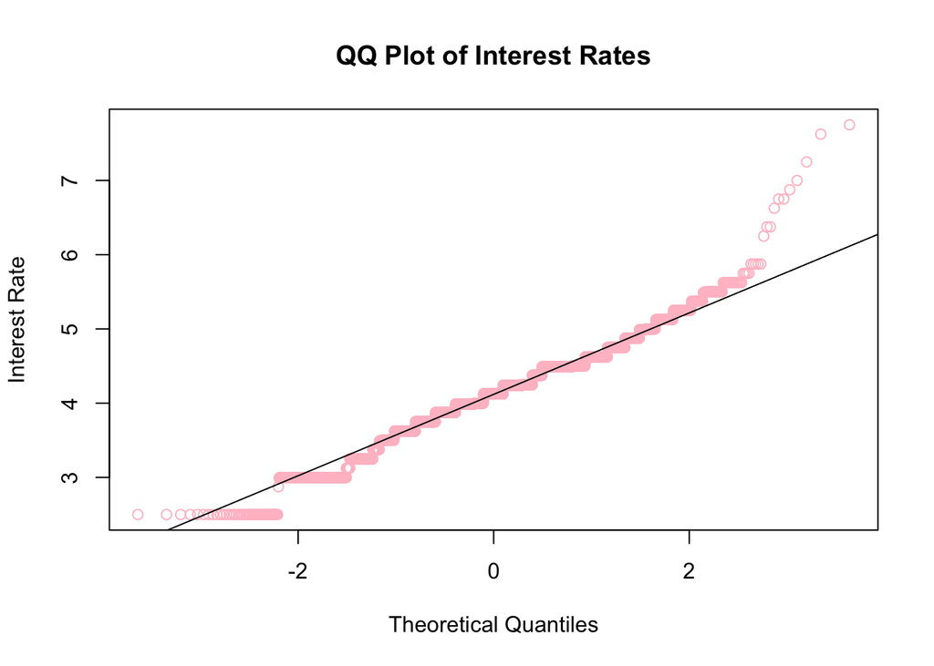

```r
qqnorm(hmda_ca_final_1$interest_rate,
       main="QQ Plot of Interest Rates",
       ylab="Interest Rate",
       col="pink")
qqline(hmda_ca_final_1$interest_rate)
```

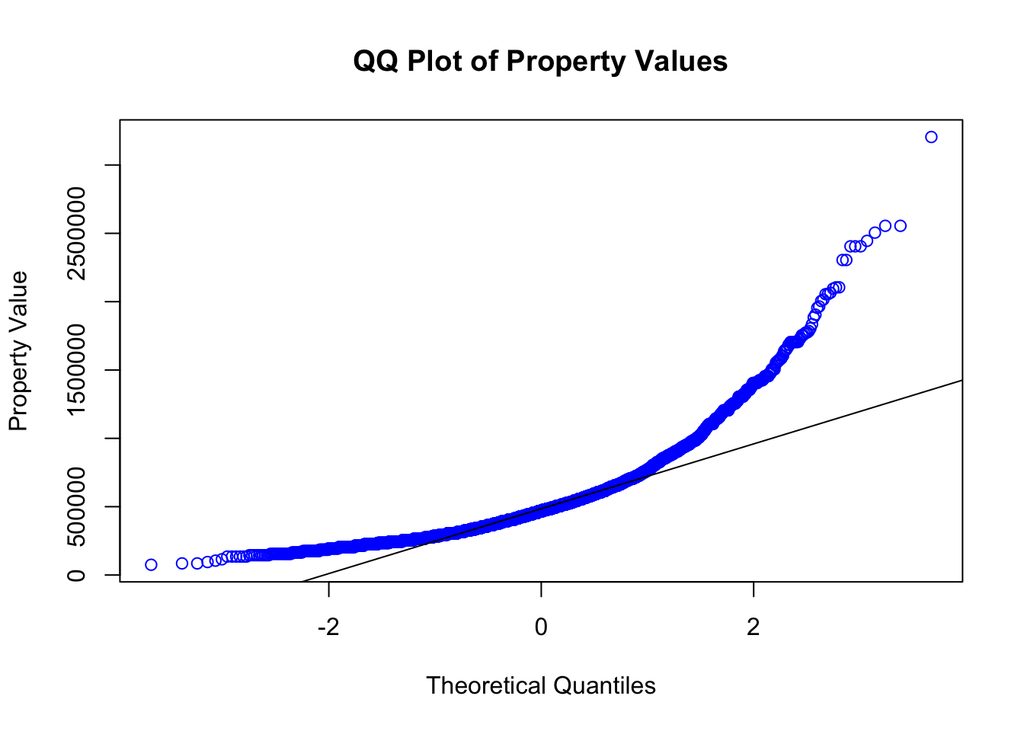

```r
qqnorm(hmda_ca_final_1$property_value,
       main="QQ Plot of Property Values",
       ylab="Property Value",
       col="blue")
qqline(hmda_ca_final_1$property_value)
```

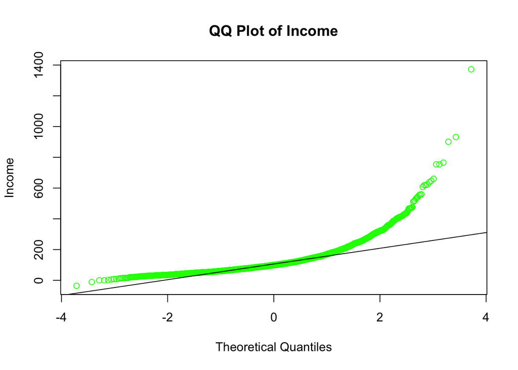

```r
qqnorm(hmda_ca_final_1$income,
       main="QQ Plot of Income",
       ylab="Income",
       col="green")
qqline(hmda_ca_final_1$income)
```

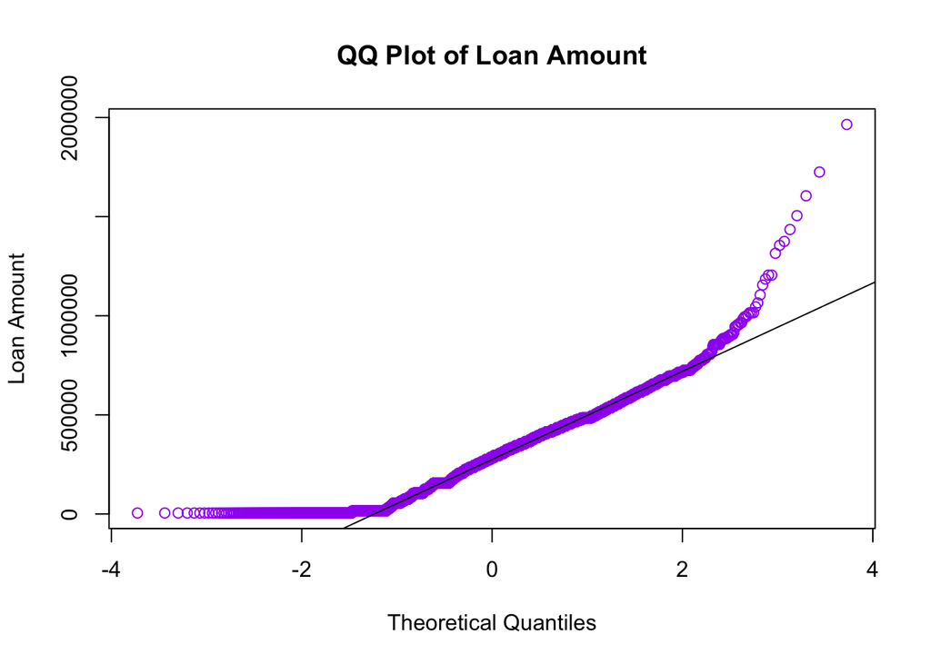

```r
qqnorm(hmda_ca_final_1$loan_amount,
       main="QQ Plot of Loan Amount",
       ylab="Loan Amount",
       col="purple")
qqline(hmda_ca_final_1$loan_amount)
```

# Removing outliers from interest_rate, property value, income, and loan amount

Can we approach more normalized distributions in loan amount, interest rates, income, and property value by removing outliers?

```r
hmda_ca_final_no_outliers_1 <- outlierKD2(hmda_ca_final_1,interest_rate)
```

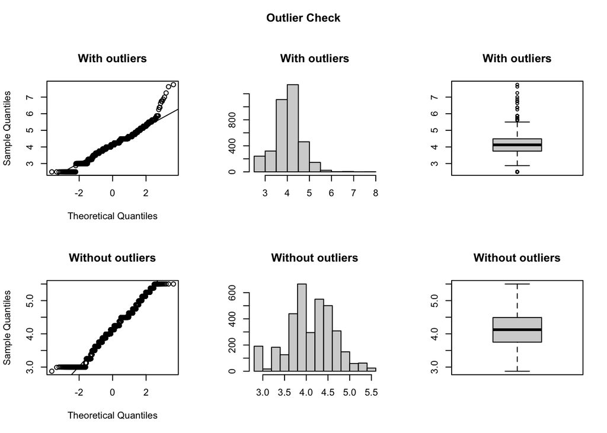

```
## Outliers identified: 85
## Propotion (%) of outliers: 2.4
## Mean of the outliers: 3.97
## Mean without removing outliers: 4.11
## Mean if we remove outliers: 4.11
## Outliers successfully removed
```

```r
hmda_ca_final_no_outliers_2 <- outlierKD2(hmda_ca_final_no_outliers_1,property_value)
```

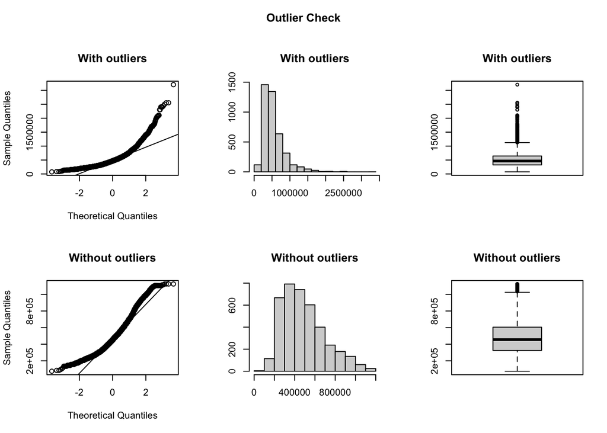

```
## Outliers identified: 214
## Propotion (%) of outliers: 5.4
## Mean of the outliers: 1454065
## Mean without removing outliers: 537499
## Mean if we remove outliers: 487917
## Outliers successfully removed
```

```r
hmda_ca_final_no_outliers_3 <- outlierKD2(hmda_ca_final_no_outliers_2,income)
```

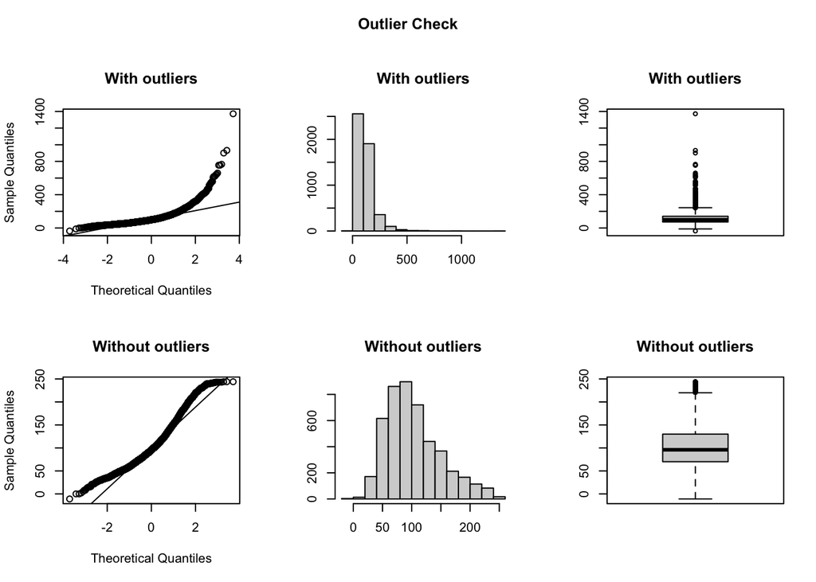

```
## Outliers identified: 295
## Propotion (%) of outliers: 6.3
## Mean of the outliers: 335
## Mean without removing outliers: 118
## Mean if we remove outliers: 104
## Outliers successfully removed
```

```r
loans <- outlierKD2(hmda_ca_final_no_outliers_3,loan_amount)
```

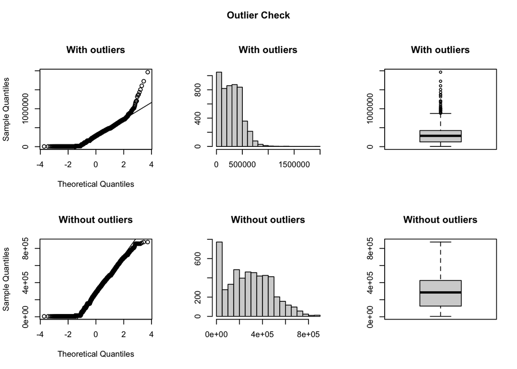

```
## Outliers identified: 40
## Propotion (%) of outliers: 0.8
## Mean of the outliers: 1093500
## Mean without removing outliers: 291310
## Mean if we remove outliers: 285027
## Outliers successfully removed
```

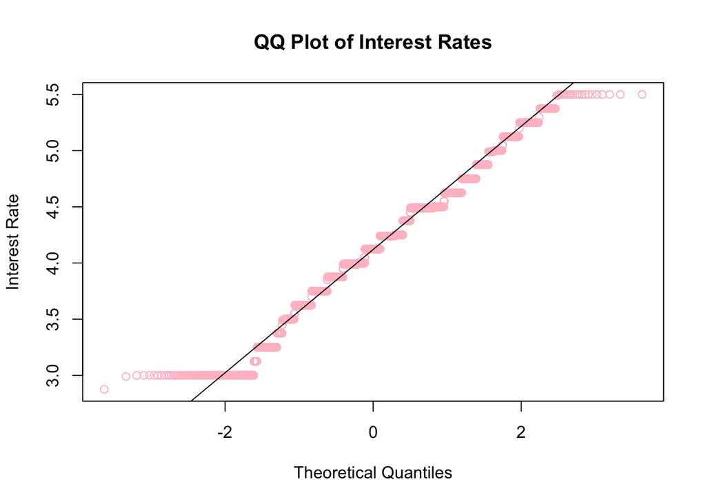

```r
qqnorm(loans$interest_rate,
       main="QQ Plot of Interest Rates",
       ylab="Interest Rate",
       col="pink")
qqline(loans$interest_rate)
```

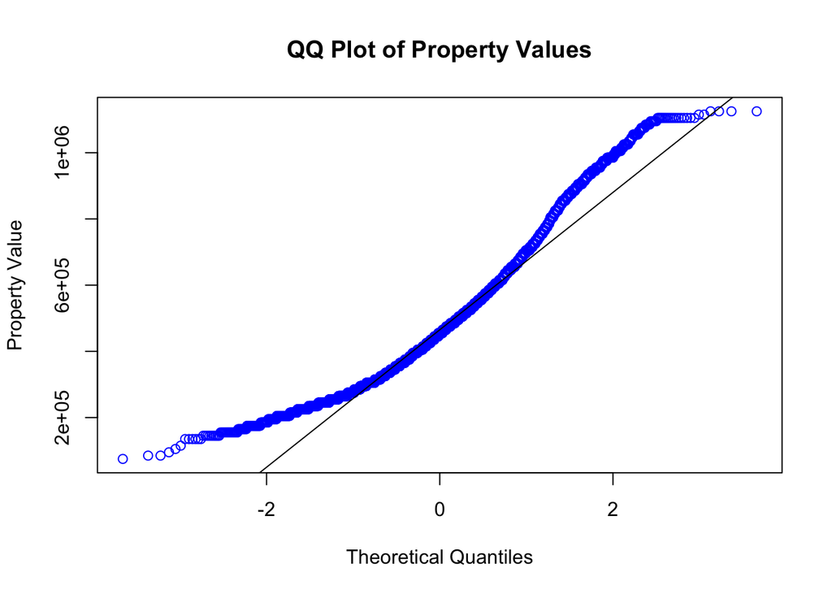

```r
qqnorm(loans$property_value,
       main="QQ Plot of Property Values",
       ylab="Property Value",
       col="blue")
qqline(loans$property_value)
```

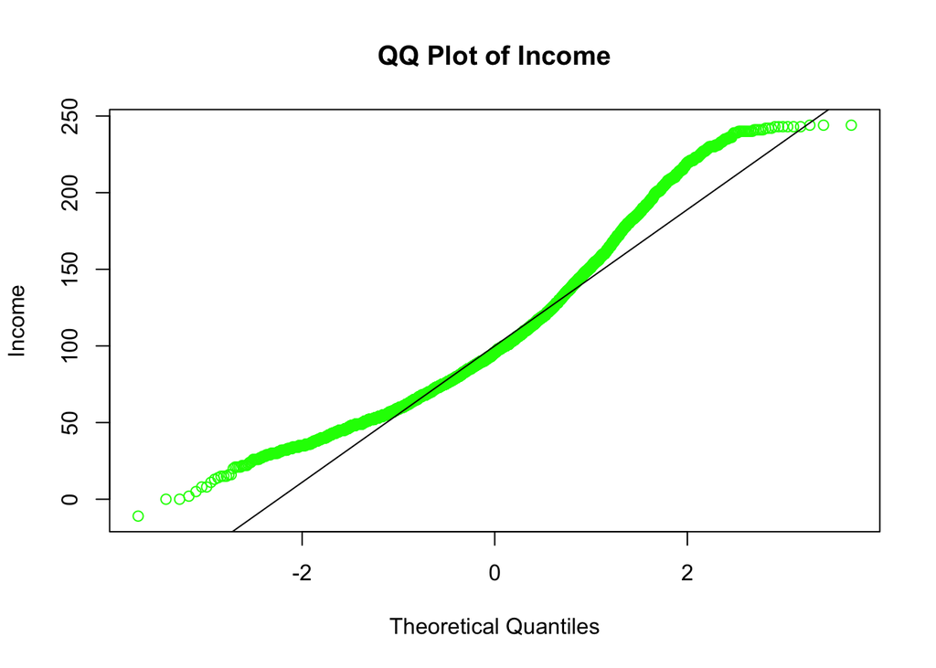

```r
qqnorm(loans$income,
       main="QQ Plot of Income",
       ylab="Income",
       col="green")
qqline(loans$income)
```

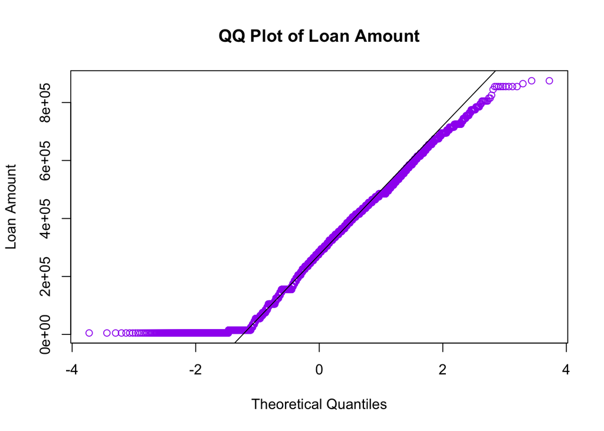

```r
qqnorm(loans$loan_amount,
       main="QQ Plot of Loan Amount",
       ylab="Loan Amount",
       col="purple")
qqline(loans$loan_amount)
```

With outliers removed, the numerical values are more normally distributed and better suited for analysis.

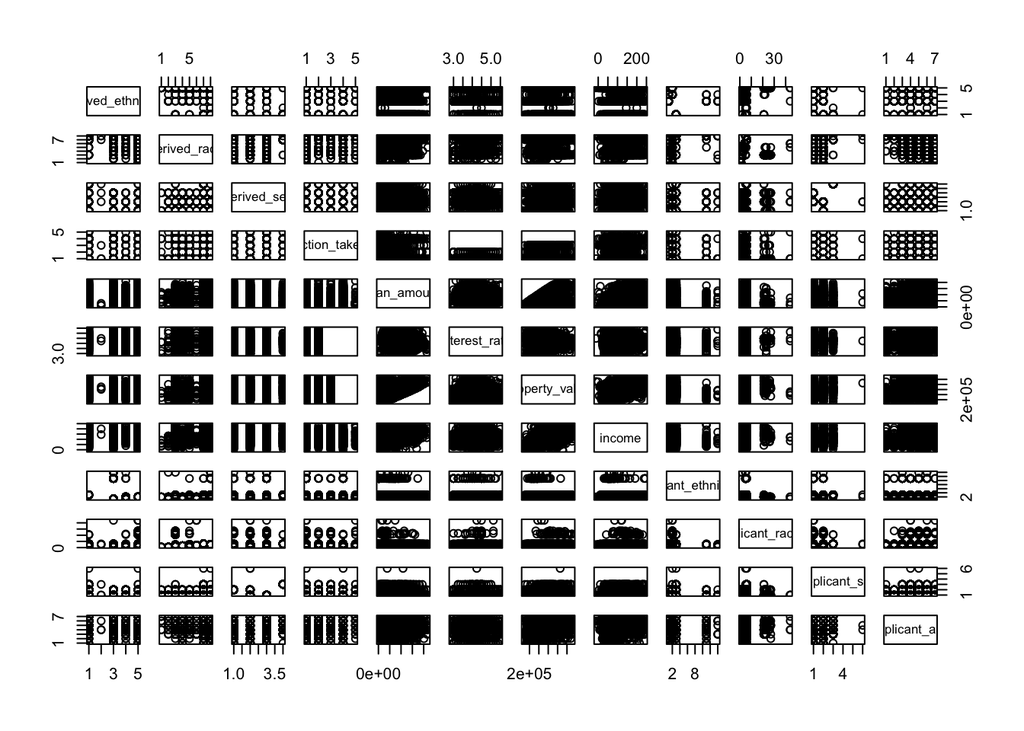

```r
library(lattice)
library(ggplot2)
pairs(loans)
```

```r
str(loans)
```

```
## 'data.frame':    5147 obs. of  12 variables:
##  $ derived_ethnicity    : Factor w/ 5 levels "Ethnicity Not Available",..: 3 4 3 3 3 3 3 1 3 3 ...
##  $ derived_race         : Factor w/ 8 levels "2 or more minority races",..: 8 8 8 8 8 8 8 7 8 8 ...
##  $ derived_sex          : Factor w/ 4 levels "Female","Joint",..: 3 2 3 1 2 3 1 4 3 3 ...
##  $ action_taken         : Factor w/ 5 levels "1","2","3","4",..: 4 4 4 1 1 4 4 4 1 1 ...
##  $ loan_amount          : num  695000 325000 345000 415000 485000 465000 495000 475000 475000 485000 ...
##  $ interest_rate        : num  NA NA NA 4.75 4.5 NA NA NA 4.75 4.5 ...
##  $ property_value       : num  NA NA NA 525000 495000 NA NA NA 475000 495000 ...
##  $ income               : num  141 126 74 90 165 112 89 112 90 112 ...
##  $ applicant_ethnicity_1: int  1 2 1 1 1 1 1 3 1 1 ...
##  $ applicant_race_1     : int  5 5 5 5 5 5 5 6 5 5 ...
##  $ applicant_sex        : int  1 1 1 2 2 1 2 3 1 1 ...
##  $ applicant_age        : Factor w/ 7 levels "<25",">74","25-34",..: 6 3 5 6 4 3 3 6 5 3 ...
```

# Correlation plot using numeric/integer values

#Creating new subset of loans data called loans_all_num which holds all numeric columns from loan dataset

```r
loans_all_num<-loans[5:11]
str(loans_all_num)
```

```
## 'data.frame':    5147 obs. of  7 variables:
##  $ loan_amount          : num  695000 325000 345000 415000 485000 465000 495000 475000 475000 485000 ...
##  $ interest_rate        : num  NA NA NA 4.75 4.5 NA NA NA 4.75 4.5 ...
##  $ property_value       : num  NA NA NA 525000 495000 NA NA NA 475000 495000 ...
##  $ income               : num  141 126 74 90 165 112 89 112 90 112 ...
##  $ applicant_ethnicity_1: int  1 2 1 1 1 1 1 3 1 1 ...
##  $ applicant_race_1     : int  5 5 5 5 5 5 5 6 5 5 ...
##  $ applicant_sex        : int  1 1 1 2 2 1 2 3 1 1 ...
```

#Creating a correlation matrix table from loans_all_num and named it cor_loans #Printed table of cor_loans #Printed corplot of cor_loans

```r
cor_loans<-cor(loans_all_num, use="complete.obs")
xkabledply(cor_loans)
```

Table

|  | loan_amount | interest_rate | property_value | income | applicant_ethnicity_1 | applicant_race_1 | applicant_sex |
| --- | --- | --- | --- | --- | --- | --- | --- |
| loan_amount | 1.0000 | 0.2274 | 0.3587 | 0.3188 | -0.0639 | -0.0325 | -0.0273 |
| interest_rate | 0.2274 | 1.0000 | 0.0894 | 0.0877 | -0.0170 | 0.0425 | 0.0338 |
| property_value | 0.3587 | 0.0894 | 1.0000 | 0.6342 | 0.0048 | 0.0914 | 0.0280 |
| income | 0.3188 | 0.0877 | 0.6342 | 1.0000 | -0.0181 | 0.0665 | -0.0120 |
| applicant_ethnicity_1 | -0.0639 | -0.0170 | 0.0048 | -0.0181 | 1.0000 | 0.0148 | 0.0266 |
| applicant_race_1 | -0.0325 | 0.0425 | 0.0914 | 0.0665 | 0.0148 | 1.0000 | 0.0048 |
| applicant_sex | -0.0273 | 0.0338 | 0.0280 | -0.0120 | 0.0266 | 0.0048 | 1.0000 |

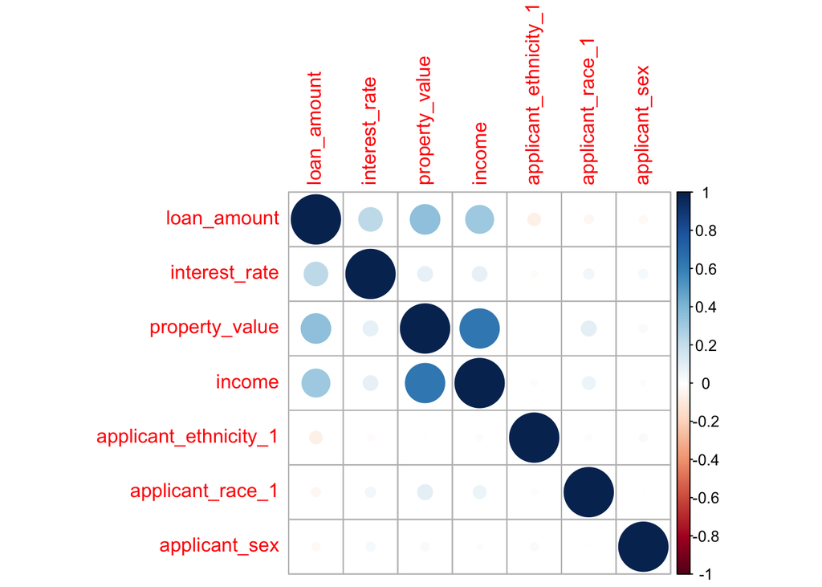

```r
loadPkg("corrplot")
corrplot(cor_loans)
```